# GeneSelectR Application on TCGA-BRCA Dataset

Damir Zhakparov

2023-12-13

# Introduction

This tutorial walks you through the use of `GeneSelectR` with the **TCGA-BRCA RNA Expression dataset** from The Cancer Genome Atlas. To acquire the dataset, we employed the `TCGAbiolinks` R package. For a step-by-step guide on data extraction, consult this script.

## Biological Question

The primary aim of this tutorial is to identify a transcriptomic signature specific to each molecular subtype of breast cancer as defined by PAM50 markers. By doing so, we hope to shed light on the unique molecular mechanisms underlying each subtype, which could subsequently inform targeted therapeutic strategies and prognostic assessments.

## Dataset Overview

In this guide, we focus on a subset of **380 samples**, all categorized under the **‘Primary Solid Tumor’** type and labeled with **PAM50 markers**: Basal(n = 80), Her2(n = 38), LumA(n = 188), and LumB (n = 74). The analysis encompasses all **60,600 sequenced transcripts**. For an in-depth look at the TCGA-BRCA dataset, please visit the official documentation. The data files used in the tutorial can be accessed here.

## Molecular Subtypes Overview

### Basal-like

- **Characteristics**: Triple Negative (HR-, HER2-), high levels of Ki-67
- **Prognosis**: Poor
- **Common Treatments**: Chemotherapy

### HER2-enriched

- **Characteristics**: HER2 Positive (HER2+), Hormone Receptor Negative (HR-)
- **Prognosis**: Intermediate
- **Common Treatments**: HER2-targeted therapies like trastuzumab

### Luminal A

- **Characteristics**: Hormone Receptor Positive (HR+), low levels of HER2 and Ki-67
- **Prognosis**: Best among the subtypes
- **Common Treatments**: Hormone therapy

### Luminal B

- **Characteristics**: Hormone Receptor Positive (HR+), higher levels of HER2 and Ki-67
- **Prognosis**: Worse than Luminal A but better than Basal-like
- **Common Treatments**: Hormone therapy, may require chemotherapy

By understanding the unique transcriptomic landscape of each subtype, we can better predict disease outcomes and tailor treatment regimens.

# 1. Differential Gene Expression Analysis

As a baseline differential gene expression analysis (DGE) provides a good starting point. First of all we will load the dataset and metadata files and import necessart packages:

```r
# set up working directories
data_dir <- file.path('../raw-data')
output_dir <- file.path('../results')

#load the files
sample_metadata <- readRDS(file.path(data_dir, 'sample_metadata.rds'))
raw_counts <- readRDS(file.path(data_dir, 'raw_counts.rds'))
```

After that we will create a DESEq2 object and then filter out genes with low counts:

```r
dds <- DESeqDataSetFromMatrix(countData = raw_counts,
                              colData = sample_metadata,
                              design = ~ paper_BRCA_Subtype_PAM50)

# filter the low counts
table(sample_metadata$paper_BRCA_Subtype_PAM50)
```

```
#>
#> Basal  Her2  LumA  LumB
#>    80    38   188    74
```

```r
smallestGroupSize <- 38 #smallest group is 38 samples
keep <- rowSums(counts(dds) >= 10) >= smallestGroupSize
dds <- dds[keep,]
```

[figure not shown]

And now let’s run the DGE analysis:

```r
# Run DESeq
dds <- DESeq(dds)
```

After the calculations are done, let’s filter out differentially expressed genes:

```r
# Get DE results
res <- results(dds)
filtered_res <- subset(res, padj < 0.001 & abs(log2FoldChange) > log2(5))
filtered_df <- as.data.frame(filtered_res)
```

And store it in a separate vector:

```r
deg_list <- rownames(filtered_df)
# Remove the two digits after ensembl id
deg_list <- gsub("\\.\\d{2}", "", deg_list)
```

# 2. Feature Selection with GeneSelectR

## 2.1 Data Preparation

GeneSelectR expects the data to be a matrix/dataframe where rows represent samples and columns are features. Please note that the dataset has to be normalized with between sample normalization prior to any analysis with the package. So now we extract the vst-transformed matrix from our DESeq2 object for the feature selection:

```r
# Extract VST (Variance-Stabilized Transformed) Data
vsd <- vst(dds, blind = FALSE)
vsd_matrix <- assay(vsd)
vsd_matrix <- t(vsd_matrix)
```

Then we will create a response vector y with sample labels:

```r
sample_metadata <- sample_metadata[match(rownames(vsd_matrix),rownames(sample_metadata)), ]
sample_metadata$paper_BRCA_Subtype_PAM50 <- as.factor(sample_metadata$paper_BRCA_Subtype_PAM50)
sample_metadata$num_label <- as.integer(sample_metadata$paper_BRCA_Subtype_PAM50) # NOTE: the labels should be encoded with numeric values
table(sample_metadata$num_label)
```

```
#>
#>   1   2   3   4
#>  80  38 188  74
```

## 2.2 Running GeneSelectR

After preparing the data we are ready to run GeneSelectR:

```r
X <-  exp
y <- sample_metadata %>% select(num_label)

selection_results <- GeneSelectR(X, # gene expression matrix
                                 y, # label vector
                                 njobs = -1, # number of cores to de deployes (-1 = all)
                                 n_splits = 5, # number of train/test splits to perform
                                 max_features = 250, # max futures to be selected per FS method (only RF, Lasso and Univariate)
                                 perform_test_split = TRUE, # if partition data into train and test
                                 scoring = 'accuracy', # scoring metric for optimization
                                 calculate_permutation_importance = TRUE, # whether to calculate permutation importance
                                 search_type = 'random', # type of grid search
                                 n_iter = 150L) # number of hyperparameter combinations to be samples
```

The ENSEMBL IDs contain a version number at the end, which is not convenient for further analysis. We can remove it by running:

```r
convert_ensembl_to_symbol <- function(selection_results) {
  target_slots <- c("inbuilt_feature_importance", "permutation_importance")

  for (slot_name in target_slots) {
    slot_content <- slot(selection_results, slot_name)

    if (!is.null(slot_content)) {
      new_slot_content <- lapply(names(slot_content), function(method) {
        df <- slot_content[[method]]

        # Remove digits after the period in feature column
        df$feature <- gsub("\\.\\d{2}", "", df$feature)

        # Convert Ensembl IDs to gene symbols
        converted <- clusterProfiler::bitr(df$feature, fromType = "ENSEMBL", toType = "SYMBOL", OrgDb = 'org.Hs.eg.db')

        # Left join to preserve all original rows
        return(merge(df, converted, by.x = "feature", by.y = "ENSEMBL", all.x = TRUE))
      })

      names(new_slot_content) <- names(slot_content)
      slot(selection_results, slot_name) <- new_slot_content
    }
  }
  return(selection_results)
}

# Apply the function
selection_results <- convert_ensembl_to_symbol(selection_results)
```

# 3. Results Inspection

After the analysis has been finished, we can look into the PipelineResults objects to inspect the results. For example if we call:

```r
str(selection_results, max.level = 2)
```

```
#> Formal class 'PipelineResults' [package "GeneSelectR"] with 6 slots
#>   ..@ best_pipeline             :List of 5
#>   ..@ cv_results                :List of 5
#>   ..@ inbuilt_feature_importance:List of 4
#>   ..@ permutation_importance    :List of 4
#>   ..@ cv_mean_score             :'data.frame':   4 obs. of  3 variables:
#>   ..@ test_metrics              : tibble [4 × 9] (S3: tbl_df/tbl/data.frame)
```

We can see following slots in the Pipeline results object: - best_pipeline - contains all the parameters for the best performing pipeline; - cv_results - contains the entire output of the CV procedure during hyperparameter search; - inbuilt_feature_importance - inbuilt feature importance with mean, std and rank for every feature across iterations;  
- permutation_importance - permutation feature importance with mean, std and rank for every feature across iterations;  
- cv_mean_scores - CV scores but agreggated into one dataframe with mean and sd of the optimization metrics scores;  
- test_metrics - metrics (f1, recall, precision and accuracy) for the unseen test set. Let’s inspect some of the most interesting metrics for the evaluation.

## 3.1 Machine Learning Performance Metrics

First, let’s explore the cross validation scores for every of our methods. We can inspect the CV mean performance by displaying the dataframe:

```r
selection_results@cv_mean_score
```

| method | mean_score | sd_score |
| --- | --- | --- |
| boruta | 0.9210374 | 0.012047342 |
| Lasso | 0.9153061 | 0.007984372 |
| RandomForest | 0.9127721 | 0.007926976 |
| Univariate | 0.9045578 | 0.011999833 |

We can see that boruta is slightly better in terms of CV performance, but all methods are somewhat comparable. In this case we can inspect the performance on unseen data that is stored in test_metrics slot:

```r
selection_results@test_metrics
```

| method | f1_mean | f1_sd | recall_mean | recall_sd | precision_mean | precision_sd | accuracy_mean | accuracy_sd |
| --- | --- | --- | --- | --- | --- | --- | --- | --- |
| Lasso | 0.8540605 | 0.03505686 | 0.8578947 | 0.03881021 | 0.8695855 | 0.02624969 | 0.8578947 | 0.03881021 |
| RandomForest | 0.8729010 | 0.03463147 | 0.8763158 | 0.03555067 | 0.8825953 | 0.02863519 | 0.8763158 | 0.03555067 |
| Univariate | 0.8590153 | 0.01273928 | 0.8631579 | 0.01500231 | 0.8656353 | 0.01361724 | 0.8631579 | 0.01500231 |
| boruta | 0.8763112 | 0.02513776 | 0.8763158 | 0.02728479 | 0.8886293 | 0.02340590 | 0.8763158 | 0.02728479 |

Again, boruta seems to be the best one, although marginally. We can produce a combined plot of all metrics by calling:

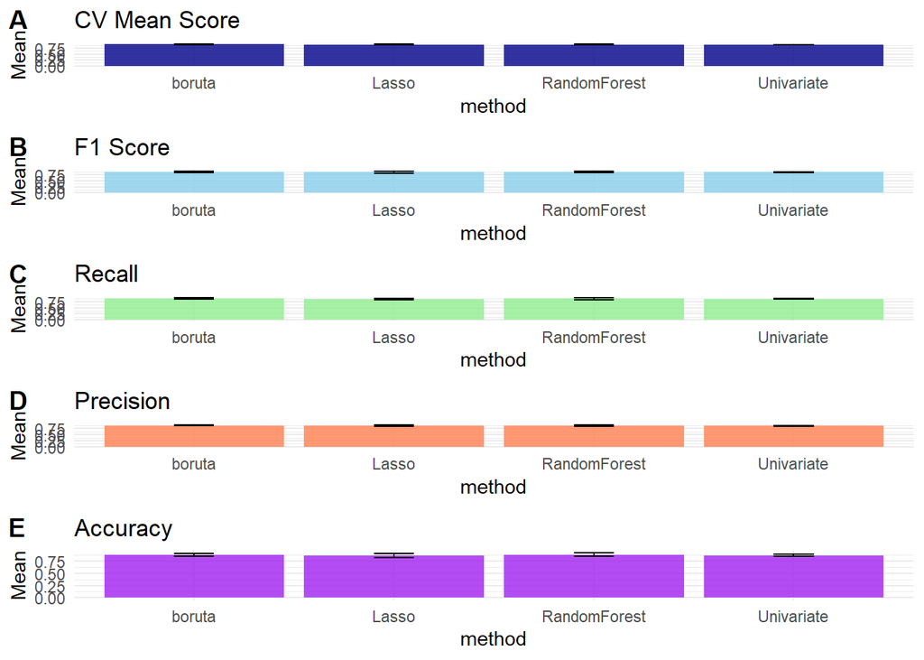

## 3.2 Feature Importance

The next step is to inspect what are the most important features for every feature selection method. To plot the importance scores we will call the plot_feature_importance(). The function returns a list of plots demonstrating mean feature importance scores across different data splits, so we will store it in a separate object:

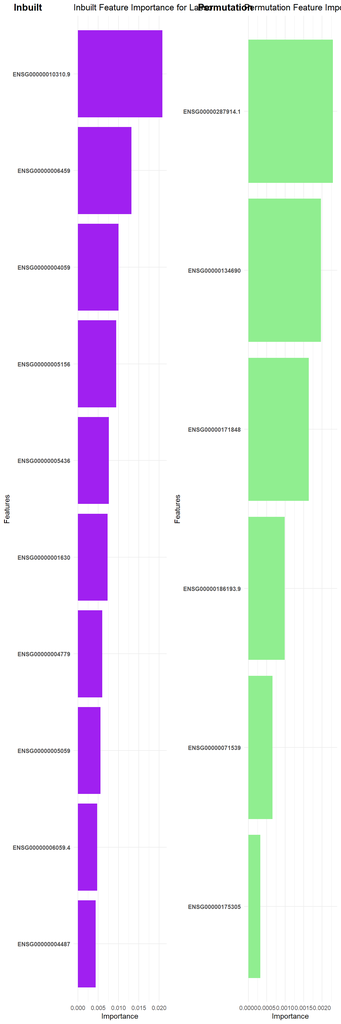

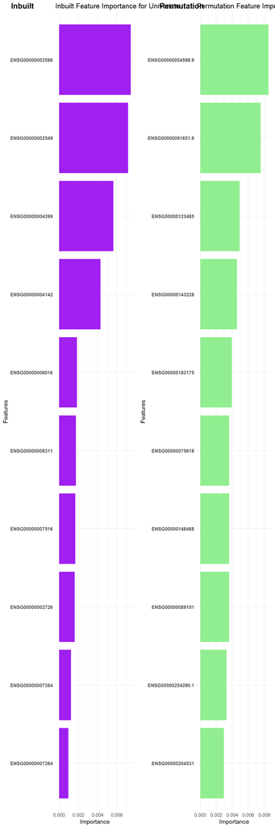

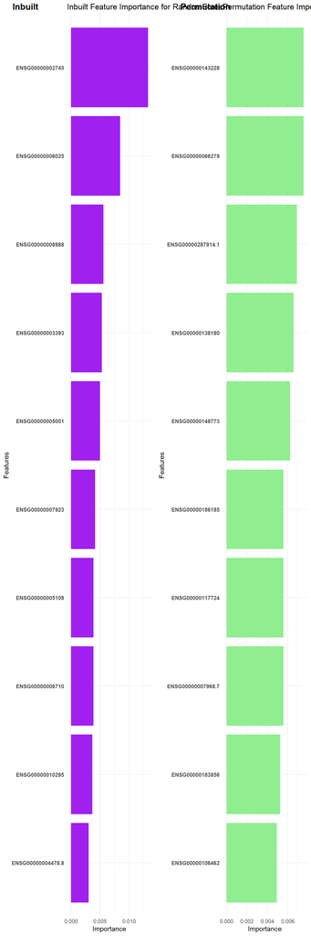

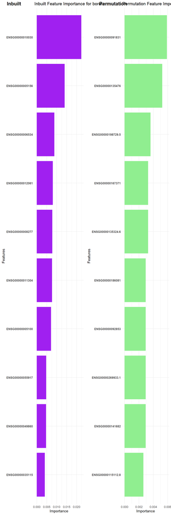

```r
plot_list <- plot_feature_importance(selection_results)
plot_list
```

Interestingly, we can see that boruta has a lot of relevant genes to cancer as top features: ENSG00000010030 (ETV7),  
ENSG00000005156 (LIG3), ENSG00000006534 (ALDH3B1), ENSG00000005100 (DHX33).

## 3.3 Overlap between Gene Lists and DGE list

It might be interesting to see if there is any overlap between the feature selection lists also including the list of differentially expressed genes. Let’s first extract the list of DEGs:

```r
deg_list <- rownames(filtered_df)
```

Then we can calculate the overlap coefficients and plot them:

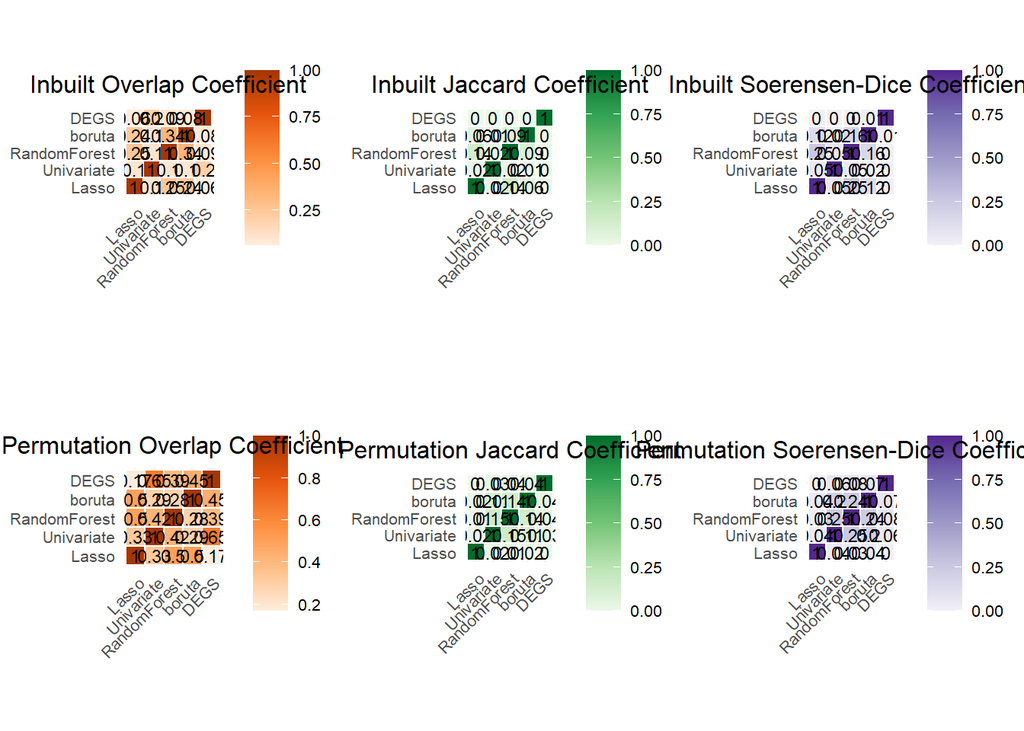

```r
#inspect overlap with DEGs
overlap_degs <- calculate_overlap_coefficients(selection_results, custom_lists = list('DEGS' = deg_list))
plot_overlap_heatmaps(overlap_degs)
```

We can see three different coefficients that calculate the list a bit differently. Since our lists are different in sizes, the most relevant one here is Overlap Coefficient. We can see that some of the permutation importance lists have similarities. For example, Lasso is quite similar to boruta and RandomForest. As for the DEGs list it’s quite similar to the Univariate method, although this is somewhat expected.

We can also inspect whethere there is an overlap with the canonical PAM50 signature. To do so we can use the following code:

```r
# load the PAM50 signature
pam50 <- read.csv(file = file.path(data_dir, 'PAM50.txt'), sep = '\t', header = FALSE, col.names = c('SYMBOL'))

# convert to ensembl ids
pam50_ens <- clusterProfiler::bitr(pam50$SYMBOL, fromType = "SYMBOL", toType = "ENSEMBL", OrgDb = 'org.Hs.eg.db')
```

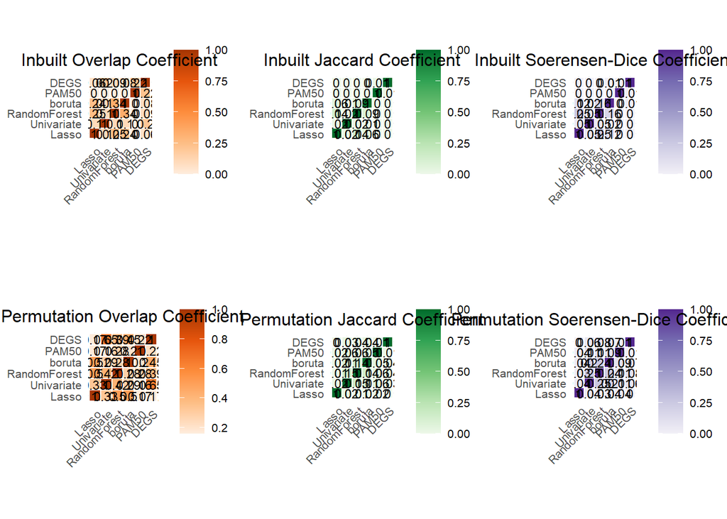

```r
#calculate the overlap with the PAM50 signature
overlap_pam50 <- calculate_overlap_coefficients(selection_results, custom_lists = list('PAM50' = pam50_ens$ENSEMBL, 'DEGS' = deg_list))
plot_overlap_heatmaps(overlap_pam50)
```

Finally, we can see the exact numbers of overlapping features by producing an UpSet plot:

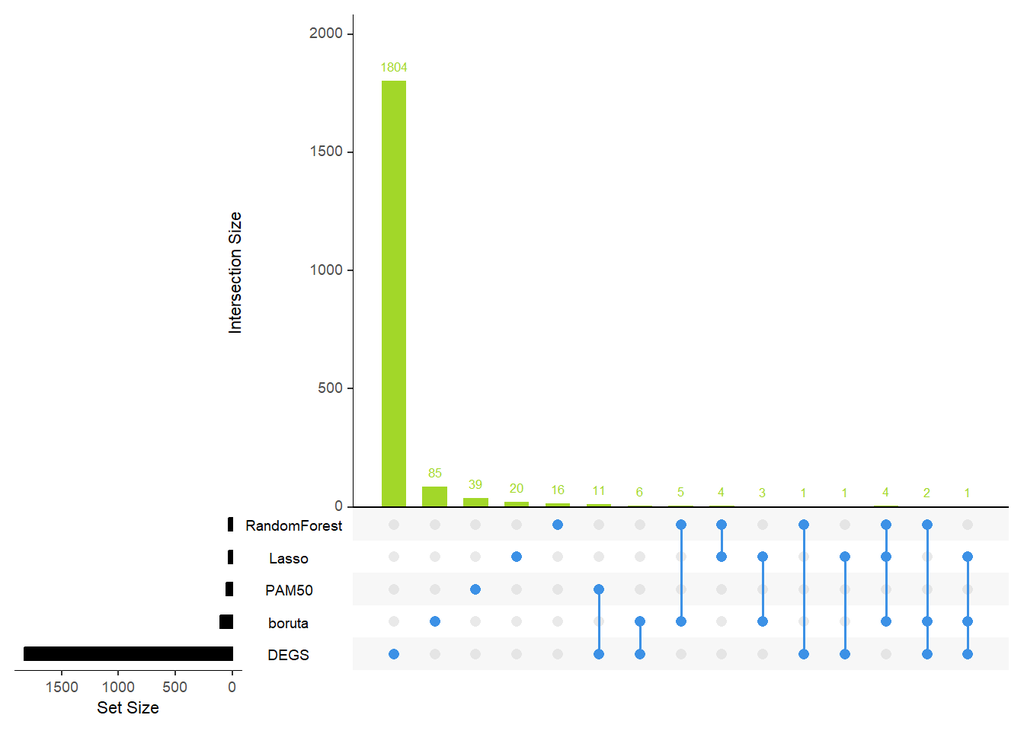

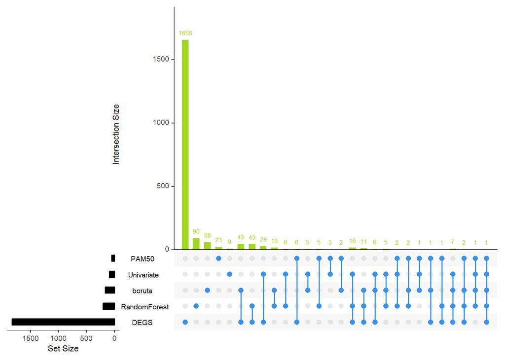

```r
plot_upset(selection_results, custom_lists = list('PAM50' = pam50_ens$ENSEMBL, 'DEGS' = deg_list))
```

## 3.4 Gene Lists Annotation

For the enrichment analysis and subsequent biological interpretation it is convenient to convert gene identifiers to others that are appropriate/useful in different situations. To do so we can do the following:

```r
# remove version number from the ensembl ids
background <- as.character(colnames(vsd_matrix))
background <- gsub("\\..*", "", background)
custom_list <- list('background' = background,
                    'DEGs' = deg_list)

ah <- AnnotationHub::AnnotationHub()
human_ens <- AnnotationHub::query(ah, c("Homo sapiens", "EnsDb"))
human_ens <- human_ens[['AH98047']]
```

```
#> loading from cache
#> require("ensembldb")
```

```r
annotations_ahb <- ensembldb::genes(human_ens, return.type = "data.frame") %>%
  dplyr::select(gene_id,gene_name,entrezid,gene_biotype)

annotations_df <- annotate_gene_lists(pipeline_results = selection_results,
                                      annotations_ahb = annotations_ahb,
                                      format = 'ENSEMBL',
                                      custom_lists = custom_list)
```

This returns an object of class AnnotatedGeneLists containing gene symbol, ENSEMBL ID and ENTREZ ID for the selected features as well as background list and DEGs list.

## 3.5 Gene Ontology Enrichment

Now we will do Gene Ontology Enrichment analysis to mine the pathways relevant to our biological question. To do so we can call the function:

```r
# perform GO Analysis
annotated_GO_inbuilt <- GO_enrichment_analysis(annotations_df,
                                       list_type = 'inbuilt', #run GO enrichment on inbuilt  selected features
                                       keyType = 'ENSEMBL', # run analysis with ENSEMBLIDs
                                       background = background,
                                       ont = 'BP') # run BP ontology
```

```
#> Performing GO Enrichment analysis for the:Lasso
#> Performing GO Enrichment analysis for the:Univariate
#> Performing GO Enrichment analysis for the:RandomForest
#> Performing GO Enrichment analysis for the:boruta
#> Performing GO Enrichment analysis for the:DEGs
```

```r
annotated_GO_permutation <- GO_enrichment_analysis(annotations_df,
                                               list_type = 'permutation', #run GO enrichment on permutation based selected features
                                               keyType = 'ENSEMBL', # run analysis with ENSEMBLIDs
                                               background = background,
                                               ont = 'BP') # run BP ontology
```

```
#> Performing GO Enrichment analysis for the:Lasso
#> Performing GO Enrichment analysis for the:Univariate
#> Performing GO Enrichment analysis for the:RandomForest
#> Performing GO Enrichment analysis for the:boruta
#> Performing GO Enrichment analysis for the:DEGs
```

So far inbuilt feature importance looked promising, so now we can inspect what GO terms are enriched in every gene list:

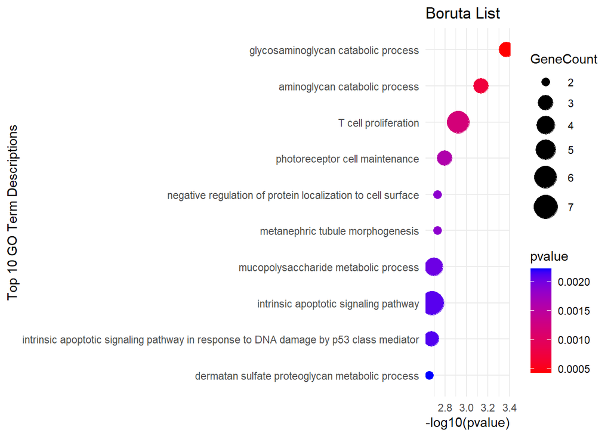

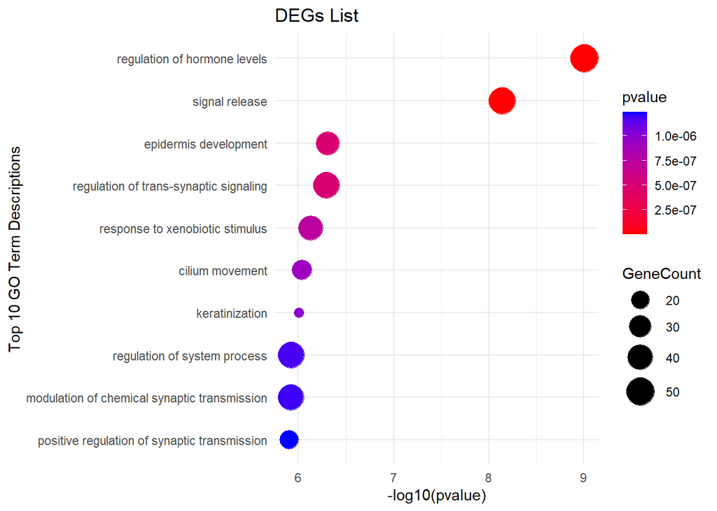

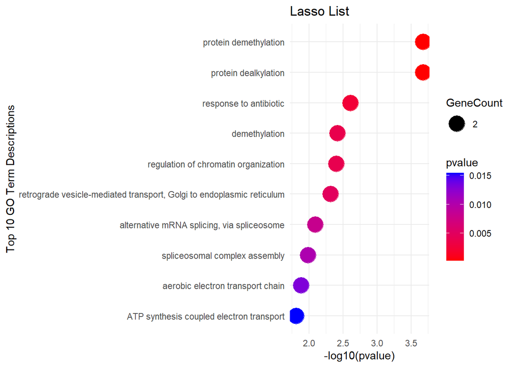

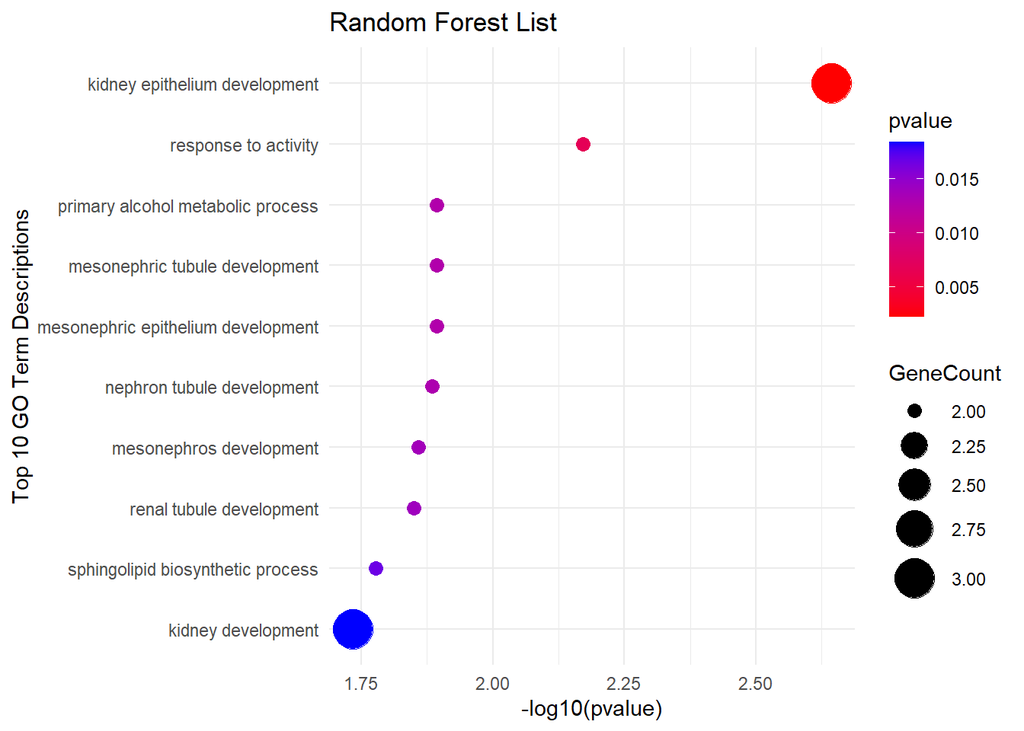

[figure not shown]

```r
ggplot(data = annotated_GO_inbuilt$RandomForest@result %>%
         arrange(pvalue) %>%
         head(10) %>%
         mutate(GeneCount = as.numeric(gsub("/.*$", "", GeneRatio))),
       aes(x = reorder(Description, -log10(pvalue)), y = -log10(pvalue))) +
  geom_point(aes(size = GeneCount, color = pvalue)) +
  scale_color_gradient(low = "red", high = "blue") +
  scale_size_continuous(range = c(3, 9)) +
  #geom_text(aes(label = GeneRatio), vjust = -1) +
  coord_flip() +
  xlab("Top 10 GO Term Descriptions") +
  ylab("-log10(pvalue)") +
  ggtitle('Univariate List') +
  theme_minimal()
```

## 3.6 Quantification of Children Nodes of Parent Node of Interest

Additionally, we can quantify how many of the children nodes of a parent node of interest are there in our list. For example, we can take two relevant broad GO Biological Process (BP) terms that are cell cycle regulation (GO:0051726) and immune response (GO:0006955).

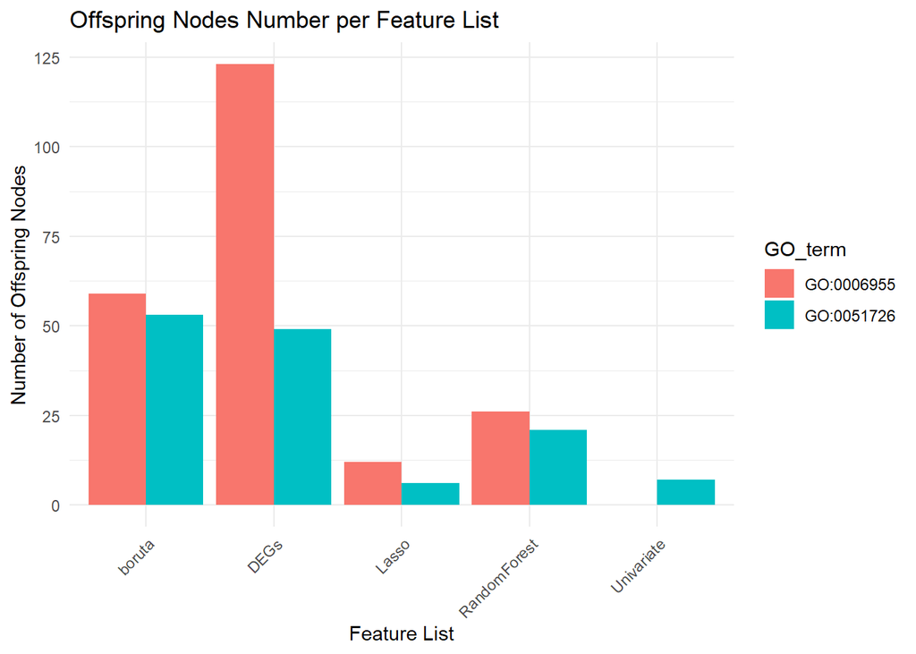

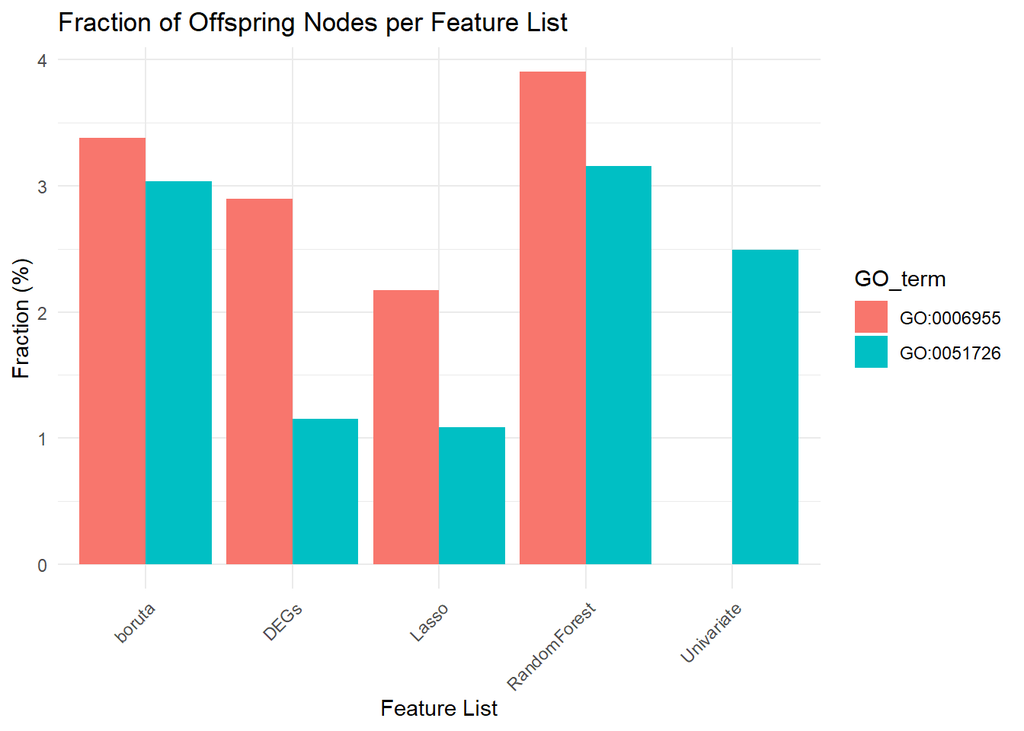

```r
annot_child_fractions_inbuilt <- compute_GO_child_term_metrics(GO_data = annotated_GO_inbuilt,
                              GO_terms = c("GO:0051726", "GO:0006955"),
                              plot = TRUE)
```

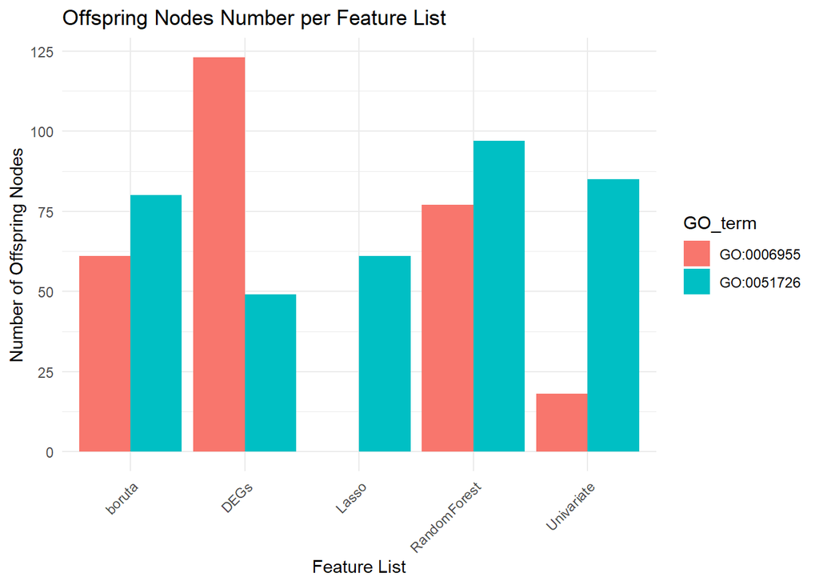

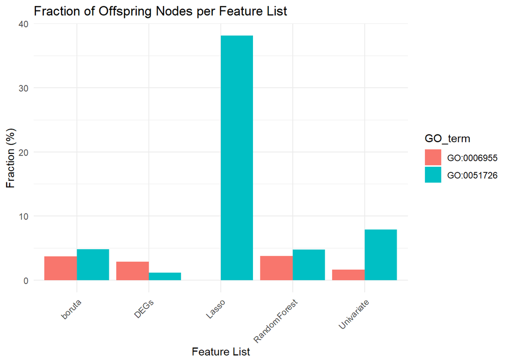

```r
annot_child_fractions_permut <- compute_GO_child_term_metrics(GO_data = annotated_GO_permutation,
                              GO_terms = c("GO:0051726", "GO:0006955"),
                              plot = TRUE)
```

## 3.7 Semantic Similarity Analysis

Finally, we can now perform semantic similarity (SS) analysis of identified GO terms. To do that we will run this:

```r
# perform SS analysis
hmap_inbuilt <- run_simplify_enrichment(annotated_GO_inbuilt,
                                method = 'louvain',
                                measure = 'Rel',
                                ont = 'BP',
                                padj_column = 'pvalue',
                                padj_cutoff = 0.01)
```

```
#> Use column 'ID' as `go_id_column`.
#> 370/4632 GO IDs left for clustering.
#> Cluster 370 terms by 'louvain'... 8 clusters, used 0.05800104 secs.
#> 'magick' package is suggested to install to give better rasterization.
#>
#> Set `ht_opt$message = FALSE` to turn off this message.
#> Perform keywords enrichment for 7 GO lists...
#> 'magick' package is suggested to install to give better rasterization.
#>
#> Set `ht_opt$message = FALSE` to turn off this message.
```

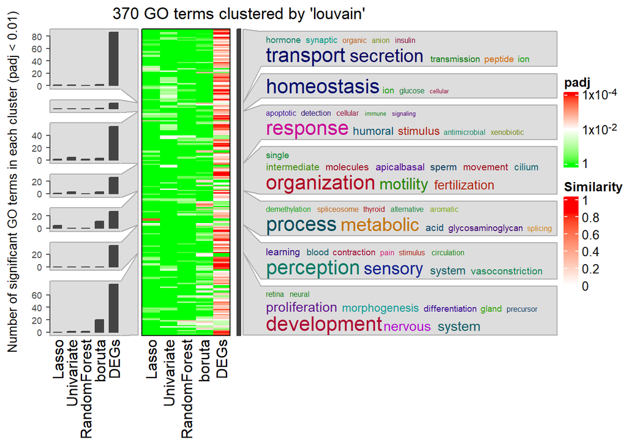

```r
hmap_permutation <- run_simplify_enrichment(annotated_GO_permutation,
                                        method = 'louvain',
                                        measure = 'Jiang',
                                        ont = 'BP',
                                        padj_column = 'pvalue',
                                        padj_cutoff = 0.01)
```

```
#> Use column 'ID' as `go_id_column`.
#> 592/4631 GO IDs left for clustering.
#> Cluster 592 terms by 'louvain'... 10 clusters, used 0.052809 secs.
#> 'magick' package is suggested to install to give better rasterization.
#>
#> Set `ht_opt$message = FALSE` to turn off this message.
#> Perform keywords enrichment for 5 GO lists...
#> 'magick' package is suggested to install to give better rasterization.
#>
#> Set `ht_opt$message = FALSE` to turn off this message.
```

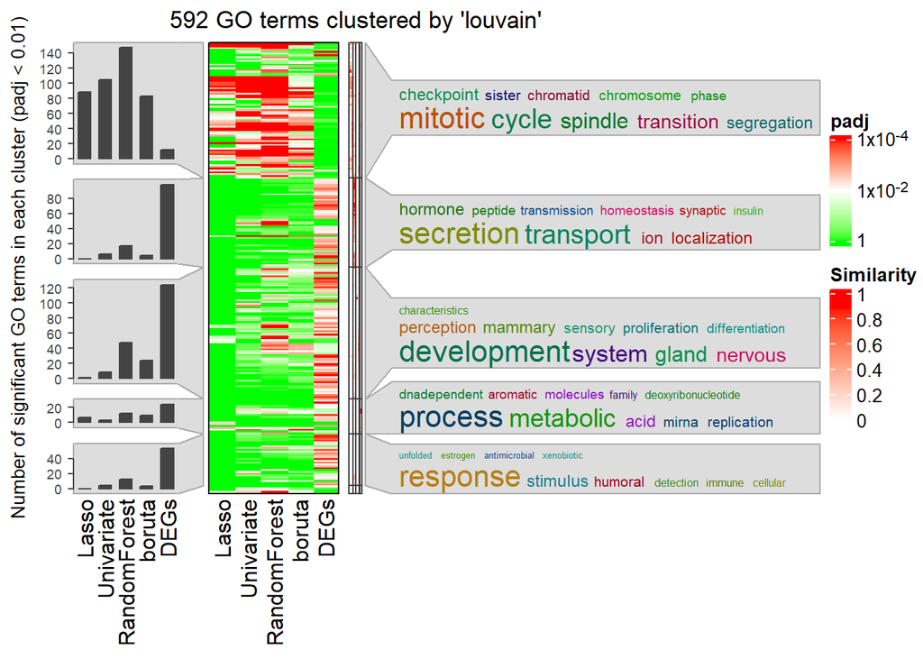

# 4. Picking the Winner and Conclusion